# **Como construir mapas isópacos utilizando R**

Dr. Fernando J. Gomez

12 de Octubre de 2017

# Objetivo

El objetivo principal de este tutorial es construir, a partir de datos estratigráficos (que pueden provenir de columnas, pozos, perfilajes, etc), **mapas isópacos** o mapas similares (ej. porcentajes litológicos y facies) usando **R**. Para esto es necesario hacer la interpolación entre puntos irregularmente espaciados (pozos de coordenadas *x*-*y*, y de espesores *z*) usando algunas de las librerías que tiene **R** para tal fin. El ejemplo en este caso es el del **Trabajo Práctico 11**. Los datos de *x*-*y*-*z* (*x* e *y* son coordenadas en planta y *z* es el espesor sedimentario). Los archivos de donde se leeran los datos y que son datos con extensión *csv* (*comma separated values*) de **EXCEL** o **LIBRE OFFICE** (*Datos_mapa_isospaco-xyz.csv* y *Datos_mapa_porcentaje_caliza-xyz.csv*) deben estar guardados en el directorio de trabajo o *working directory* de **R**. Para saber cual es el directorio de trabajo puede escribirse *getwd()*. Para definir otro *working directory* se usa *setwd()* por lo que puede escribirse, por ejemplo *setwd(“C:/Documents and Settings/Data”)*. Los gráficos resultantes se guardaran automáticamente en este directorio definido (y allí ademas deberia estar guardado el archivo *csv* con los datos a plotear).

# Procedimiento

## Instalar **R** y las librerias a utilizar

El programa **R** puede instalarse del siguiente link: https://cran.r-project.org/. Para construir nuestro mapa, para interpolar y graficar usaremos dos paquetes o librerías de **R** (que deben ser instaladas en caso que no lo esten), estas librerías son **akima** y **fields**.

Para Instalar estas librerías se puede ir a *tools* y luego *install packages* y buscar las librerías de interes.

**Nota**: Las lineas que inician con el numeral (#) no son leídas por R.

## Luego debemos llamar las librerias para utilizarlas

```r
library(akima);
library(fields);
#esta linea lee la Tabla de datos que previamente fue guardada con extension
#cvs, y genera un data.frame que aqui llamamos "mydata"
mydata = data.frame(read.csv("Datos_mapa_isospaco-xyz.csv"))

#podemos escribir mydata en caso de de que queramos ver el set de datos a usar
mydata
```

```
##       x    y    z
## 1   3.0 19.0    0
## 2   2.0 17.0    0
## 3   3.2 18.5   30
## 4   5.0 19.2  320
## 5   7.0 16.0 1120
## 6  12.5 19.0 1130
## 7  12.8 14.5  650
## 8   3.8 14.0  805
## 9   8.0 13.5  890
## 10 12.0 13.5  710
## 11 12.5 10.5  610
## 12  1.5  9.8  605
## 13  5.0  9.0  810
## 14  7.3  8.7  700
## 15  8.5  8.0  660
## 16 13.0  7.0    6
## 17  3.0  5.8  690
## 18  3.6  4.5  670
## 19  2.5  1.6  720
## 20  6.0  3.8  730
## 21  7.0  1.8  530
## 22  8.5  5.0  690
## 23 10.0  1.0  150
## 24 11.0  2.3    0
## 25 11.0  4.0   30
## 26 12.0  8.5  360
```

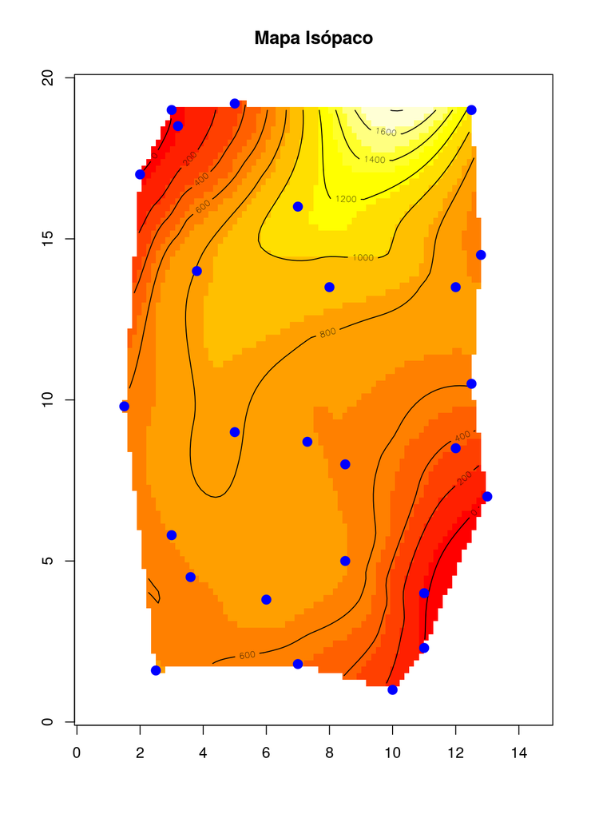

```r
#extraemos los valores x, y, z de mydata y los asignamos a x, y, z.
x<-mydata$x
y<-mydata$y
z<-mydata$z


#interpolamos usando akima (elegimos spline que es el metodo de interpolacion
#al escribir "linear=FALSE")
# elegimos el rango de valores de "x"" e "y".
akima.spl <- with(mydata, interp(x,y,z, xo=seq(0,15, length=100),
                                       yo=seq(0,20, length=100),
                                linear=FALSE))
#Luego ploteamos usando "image" para generar el grafico de colore
#Usamos"contour" para plotear las lineas isopacas
#usamos "points" para plotear los puntos de ubicacion de pozos
image(akima.spl, main = "Mapa Isópaco")
contour(akima.spl, add=TRUE)
points(mydata, pch = 20, cex = 2, col = "blue")
```

## Lo mismo se puede hacerse en el caso de porcentajes de calizas

En este caso simplemente cambiamos el archivo de donde se leeran los datos para hacer el grafico (*Datos_mapa_porcentaje_caliza-xyz.csv*). Abajo va el script completo.

```r
library(akima);
library(fields)
mydata = data.frame(read.csv("Datos_mapa_porcentaje_caliza-xyz.csv"))
mydata
```

```
##       x    y   z
## 1   3.0 19.0 100
## 2   2.0 17.0   0
## 3   3.2 18.5 100
## 4   5.0 19.2 100
## 5   7.0 16.0 100
## 6  12.5 19.0 100
## 7  12.8 14.5  75
## 8   3.8 14.0  95
## 9   8.0 13.5  75
## 10 12.0 13.5  45
## 11 12.5 10.5   5
## 12  1.5  9.8  50
## 13  5.0  9.0  55
## 14  7.3  8.7  30
## 15  8.5  8.0   5
## 16 13.0  7.0   0
## 17  3.0  5.8  35
## 18  3.6  4.5  20
## 19  2.5  1.6  10
## 20  6.0  3.8   8
## 21  7.0  1.8   0
## 22  8.5  5.0   3
## 23 10.0  1.0   0
## 24 11.0  2.3   0
## 25 11.0  4.0   0
## 26 12.0  8.5   0
```

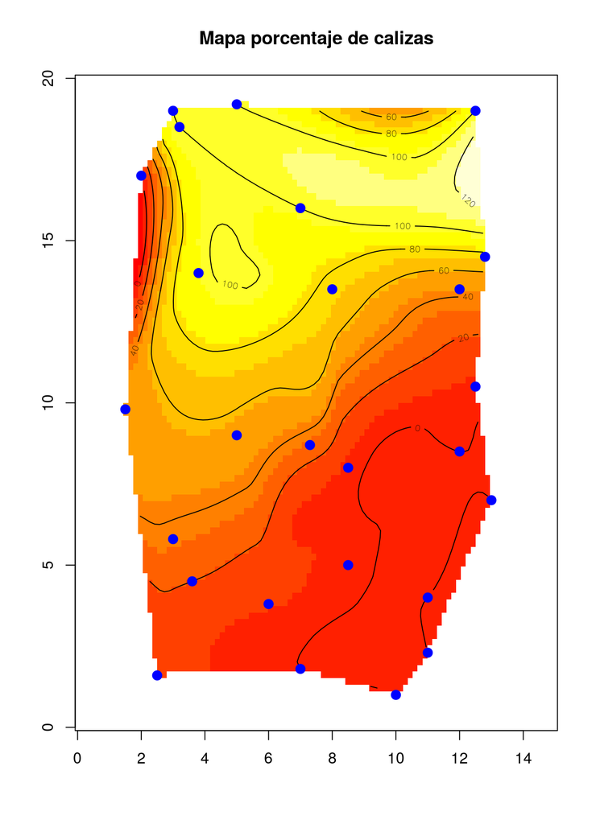

```r
x<-mydata$x
y<-mydata$y
z<-mydata$z

akima.spl <- with(mydata, interp(x,y,z, xo=seq(0,15, length=100),
                                       yo=seq(0,20, length=100),
                                linear=FALSE))
image(akima.spl, main = "Mapa porcentaje de calizas")
contour(akima.spl, add=TRUE)
points(mydata, pch = 20, cex = 2, col = "blue")
```